# Machine Learning Course Project

Weight Lifting Exercise Prediction

Angus Chadney

17 November 2015

## Introduction

Using devices such as Jawbone Up, Nike FuelBand, and Fitbit it is now possible to collect a large amount of data about personal activity relatively inexpensively. These type of devices are part of the quantified self movement - a group of enthusiasts who take measurements about themselves regularly to improve their health, to find patterns in their behavior, or because they are tech geeks. One thing that people regularly do is quantify how much of a particular activity they do, but they rarely quantify how well they do it. In this project, your goal will be to use data from accelerometers on the belt, forearm, arm, and dumbell of 6 participants. They were asked to perform barbell lifts correctly and incorrectly in 5 different ways. More information is available from the website here: http://groupware.les.inf.puc-rio.br/har (see the section on the Weight Lifting Exercise Dataset).

### Task

“The goal of your project is to predict the manner in which they did the exercise. This is the”classe" variable in the training set. You may use any of the other variables to predict with. You should create a report describing how you built your model, how you used cross validation, what you think the expected out of sample error is, and why you made the choices you did. You will also use your prediction model to predict 20 different test cases."

### Data

The training data for this project are available here: https://d396qusza40orc.cloudfront.net/predmachlearn/pml-training.csv

The test data are available here: https://d396qusza40orc.cloudfront.net/predmachlearn/pml-testing.csv

Six young health participants were asked to perform one set of 10 repetitions of the Unilateral Dumbbell Biceps Curl in five different fashions: exactly according to the specification (Class A), throwing the elbows to the front (Class B), lifting the dumbbell only halfway (Class C), lowering the dumbbell only halfway (Class D) and throwing the hips to the front (Class E).

### Citation

Velloso, E.; Bulling, A.; Gellersen, H.; Ugulino, W.; Fuks, H. Qualitative Activity Recognition of Weight Lifting Exercises. Proceedings of 4th International Conference in Cooperation with SIGCHI (Augmented Human ’13) . Stuttgart, Germany: ACM SIGCHI, 2013.

## Code Time

### Initialisation

```r
# Libraries
library(caret)
library(rattle)
library(rpart)
library(randomForest)
# Set random num seed
set.seed(123)

# Max number of na's we're allowing in the train dataset columns (used later)
max_na <- 19200
```

### Getting the data

```r
# Grab the files from the interwebs
url_train <- "https://d396qusza40orc.cloudfront.net/predmachlearn/pml-training.csv"
#download.file(url=url_train, destfile=pml-training.csv)
url_test <- "https://d396qusza40orc.cloudfront.net/predmachlearn/pml-testing.csv"
#download.file(url=url_test, destfile=pml-testing.csv)

# Load the files in to R, na strings obtained from observation
train_data <- read.csv("./pml-training.csv", na.strings = c("NA", "", "#DIV/0!"))
test_data <- read.csv("./pml-testing.csv", na.strings = c("NA", "", "#DIV/0!"))

# Remove those columns in the train dataset that have too many NAs.  19200 was chosen by observation
train_data <- train_data[, apply(train_data, 2, function(x) sum(is.na(x)) <= max_na)]

# Get rid of the non-numeric columns at the start (timestamp etc.)
train_data <- train_data[, 8:60]

# Coerce all columns but "classe" in the train dataset to numeric (read.csv makes them factors and ints as well)
train_data[, -53] <- sapply(train_data[, -53], as.numeric)

# Make sure that the test data is using the same columns
test_data <- test_data[, which(names(test_data) %in% names(train_data))]
```

### Preprocessing

Firstly, lets use the nearZeroVar function to check if there are any features that have very little variance, and will therefore not contribute very much to the prediction function.

```r
nsv <- nearZeroVar(train_data, saveMetrics=TRUE)
nsv
```

```
##                      freqRatio percentUnique zeroVar   nzv
## roll_belt             1.101904     6.7781062   FALSE FALSE
## pitch_belt            1.036082     9.3772296   FALSE FALSE
## yaw_belt              1.058480     9.9734991   FALSE FALSE
## total_accel_belt      1.063160     0.1477933   FALSE FALSE
## gyros_belt_x          1.058651     0.7134849   FALSE FALSE
## gyros_belt_y          1.144000     0.3516461   FALSE FALSE
## gyros_belt_z          1.066214     0.8612782   FALSE FALSE
## accel_belt_x          1.055412     0.8357966   FALSE FALSE
## accel_belt_y          1.113725     0.7287738   FALSE FALSE
## accel_belt_z          1.078767     1.5237998   FALSE FALSE
## magnet_belt_x         1.090141     1.6664968   FALSE FALSE
## magnet_belt_y         1.099688     1.5187035   FALSE FALSE
## magnet_belt_z         1.006369     2.3290184   FALSE FALSE
## roll_arm             52.338462    13.5256345   FALSE FALSE
## pitch_arm            87.256410    15.7323412   FALSE FALSE
## yaw_arm              33.029126    14.6570176   FALSE FALSE
## total_accel_arm       1.024526     0.3363572   FALSE FALSE
## gyros_arm_x           1.015504     3.2769341   FALSE FALSE
## gyros_arm_y           1.454369     1.9162165   FALSE FALSE
## gyros_arm_z           1.110687     1.2638875   FALSE FALSE
## accel_arm_x           1.017341     3.9598410   FALSE FALSE
## accel_arm_y           1.140187     2.7367241   FALSE FALSE
## accel_arm_z           1.128000     4.0362858   FALSE FALSE
## magnet_arm_x          1.000000     6.8239731   FALSE FALSE
## magnet_arm_y          1.056818     4.4439914   FALSE FALSE
## magnet_arm_z          1.036364     6.4468454   FALSE FALSE
## roll_dumbbell         1.022388    84.2065029   FALSE FALSE
## pitch_dumbbell        2.277372    81.7449801   FALSE FALSE
## yaw_dumbbell          1.132231    83.4828254   FALSE FALSE
## total_accel_dumbbell  1.072634     0.2191418   FALSE FALSE
## gyros_dumbbell_x      1.003268     1.2282132   FALSE FALSE
## gyros_dumbbell_y      1.264957     1.4167771   FALSE FALSE
## gyros_dumbbell_z      1.060100     1.0498420   FALSE FALSE
## accel_dumbbell_x      1.018018     2.1659362   FALSE FALSE
## accel_dumbbell_y      1.053061     2.3748853   FALSE FALSE
## accel_dumbbell_z      1.133333     2.0894914   FALSE FALSE
## magnet_dumbbell_x     1.098266     5.7486495   FALSE FALSE
## magnet_dumbbell_y     1.197740     4.3012945   FALSE FALSE
## magnet_dumbbell_z     1.020833     3.4451126   FALSE FALSE
## roll_forearm         11.589286    11.0895933   FALSE FALSE
## pitch_forearm        65.983051    14.8557741   FALSE FALSE
## yaw_forearm          15.322835    10.1467740   FALSE FALSE
## total_accel_forearm   1.128928     0.3567424   FALSE FALSE
## gyros_forearm_x       1.059273     1.5187035   FALSE FALSE
## gyros_forearm_y       1.036554     3.7763735   FALSE FALSE
## gyros_forearm_z       1.122917     1.5645704   FALSE FALSE
## accel_forearm_x       1.126437     4.0464784   FALSE FALSE
## accel_forearm_y       1.059406     5.1116094   FALSE FALSE
## accel_forearm_z       1.006250     2.9558659   FALSE FALSE
## magnet_forearm_x      1.012346     7.7667924   FALSE FALSE
## magnet_forearm_y      1.246914     9.5403119   FALSE FALSE
## magnet_forearm_z      1.000000     8.5771073   FALSE FALSE
## classe                1.469581     0.0254816   FALSE FALSE
```

Looks good! There don’t seem to be any variables that we should be excluding.

Secondly, lets have a look at the cross correlation between the features.

```r
cor_cols <- findCorrelation(cor(train_data[,-53]), cutoff=0.95)
names(train_data[, cor_cols])
```

```
## [1] "accel_belt_z"     "roll_belt"        "accel_belt_x"
## [4] "gyros_dumbbell_z"
```

Okay, these variables are highly correlated, lets remove them.

```r
train_data <- train_data[, -cor_cols]
test_data <- test_data[, -cor_cols]
```

### Creating partitions

I chose to split the dataset up into 4 equal parts. Mainly so the algo’s aren’t so slow, but also to give me two training sets, and two equal sized test sets for cross-validation.

```r
# Split off 25% (leaving 75% of total)
idx <- createDataPartition(train_data$classe, p=1/4, list=FALSE)
train1 <- train_data[idx,]
temp_data <- train_data[-idx,]
# Split off 33% (leaving 50% of total)
idx <- createDataPartition(temp_data$classe, p=1/3, list=FALSE)
train2 <- temp_data[idx,]
temp_data <- temp_data[-idx,]
# Split off 50% (leaving 25% of total)
idx <- createDataPartition(temp_data$classe, p=1/2, list=FALSE)
test1 <- temp_data[idx,]
test2 <- temp_data[-idx,]
```

### Algorithm 1 - Standard classification tree

As this is a classification of a factor variable problem, the go-to algo should be the standard classification tree. I will create a model using the $train1$ set, predict the outcome on $test1$, then compute the out of sample error by using the confusionMatrix. Please refer to the appendix for a fancy plot showing the decision tree model.

```r
# Standard classification tree algo
modFit1 <- rpart(classe ~ ., data=train1, method="class")
pred1 <- predict(modFit1, test1, type="class")
cm1 <- confusionMatrix(pred1, test1$classe)

# Print confusion matrix
cm1$table
```

```
##           Reference
## Prediction    A    B    C    D    E
##          A 1194  152   79   79   30
##          B   62  555   44   22   96
##          C   76  127  613   91   63
##          D   62  105  100  606  101
##          E    1   10   19    6  612
```

```r
# Extract the accuracy from the confusionMatrix
acc1 <- cm1$overall[1]
# Out of sample error rate is 1 - accuracy
err1 <- 1 - acc1
print(paste0('Out of sample error rate on test1: ', round(err1, 3)*100, '%'))
```

```
## [1] "Out of sample error rate on test1: 27%"
```

Now let’s cross validate by running the same analysis on $train2$ / $test2$, and averaging the results.

```r
# Standard classification tree algo
modFit2 <- rpart(classe ~ ., data=train2, method="class")
pred2 <- predict(modFit2, test2, type="class")
cm2 <- confusionMatrix(pred2, test2$classe)

# Print confusion matrix
cm2$table
```

```
##           Reference
## Prediction    A    B    C    D    E
##          A 1294  219   28   81   63
##          B   38  555   90   44  146
##          C   27   73  572   52  105
##          D   26   70  136  562   52
##          E   10   32   29   65  535
```

```r
# Extract the accuracy from the confusionMatrix
acc2 <- cm2$overall[1]
# Out of sample error rate is 1 - accuracy
err2 <- 1 - acc2
print(paste0('Out of sample error rate on test1: ', round(err2, 3)*100, '%\n'))
```

```
## [1] "Out of sample error rate on test1: 28.3%\n"
```

```r
print(paste0('Average out of sample error rate: ', round(mean(c(err1, err2)), 3)*100, '%\n'))
```

```
## [1] "Average out of sample error rate: 27.6%\n"
```

### Algorithm 2 - Random forest

```r
# Standard classification tree algo
modFit3 <- randomForest(classe ~ ., data=train1, method="class")
pred3 <- predict(modFit3, test1, type="class")
cm3 <- confusionMatrix(pred3, test1$classe)

# Print confusion matrix
cm3$table
```

```
##           Reference
## Prediction    A    B    C    D    E
##          A 1390   29    0    0    0
##          B    4  908   27    0    0
##          C    0   11  821   20    9
##          D    0    0    6  784    3
##          E    1    1    1    0  890
```

```r
# Extract the accuracy from the confusionMatrix
acc3 <- cm3$overall[1]
# Out of sample error rate is 1 - accuracy
err3 <- 1 - acc3
print(paste0('Out of sample error rate on test1: ', round(err3, 3)*100, '%'))
```

```
## [1] "Out of sample error rate on test1: 2.3%"
```

Cross validating again by running the same analysis on $train2$ / $test2$, and averaging the results.

```r
# Standard classification tree algo
modFit4 <- randomForest(classe ~ ., data=train2, method="class")
pred4 <- predict(modFit4, test2, type="class")
cm4 <- confusionMatrix(pred4, test2$classe)

# Print confusion matrix
cm4$table
```

```
##           Reference
## Prediction    A    B    C    D    E
##          A 1392   25    0    3    0
##          B    1  910   11    0    2
##          C    0   13  837   17   10
##          D    0    0    7  782    1
##          E    2    1    0    2  888
```

```r
# Extract the accuracy from the confusionMatrix
acc4 <- cm4$overall[1]
# Out of sample error rate is 1 - accuracy
err4 <- 1 - acc4
print(paste0('Out of sample error rate on test1: ', round(err4, 3)*100, '%'))
```

```
## [1] "Out of sample error rate on test1: 1.9%"
```

```r
print(paste0('Average out of sample error rate: ', round(mean(c(err3, err4)), 3)*100, '%\n'))
```

```
## [1] "Average out of sample error rate: 2.1%\n"
```

## Predicting on test data

Our best model (lowest out of sample error rate) was number 4, therefore we will use that to predict $classe$ for the test data.

```r
pred_on_test <- predict(modFit4, test_data, type="class")
pred_on_test
```

```
##  1  2  3  4  5  6  7  8  9 10 11 12 13 14 15 16 17 18 19 20
##  B  A  B  A  A  E  D  B  A  A  B  C  B  A  E  E  A  B  B  B
## Levels: A B C D E
```

And finally, use the below function to create the requisite output files:

```r
pml_write_files = function(x){
    n = length(x)
    for(i in 1:n){
        filename = paste0("problem_id_",i,".txt")
        write.table(x[i],file=filename,quote=FALSE,row.names=FALSE,col.names=FALSE)
    }
}

pml_write_files(pred_on_test)
```

## Appendix

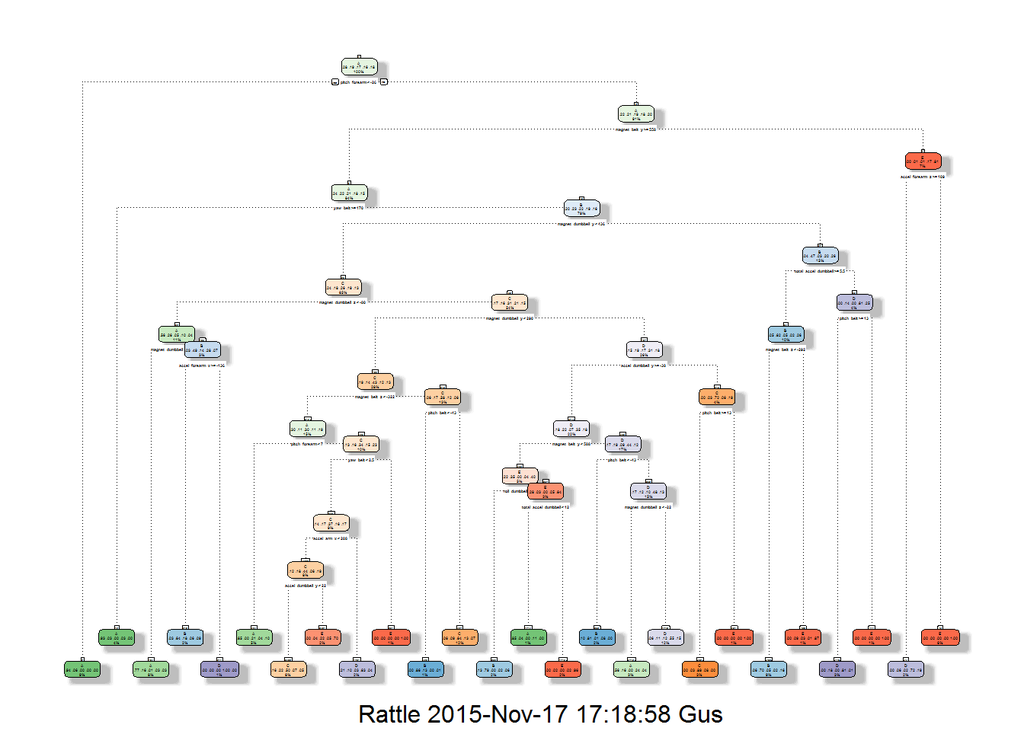